# Advertising ROI Case Study

Ingram Micro Interview, 2018-03-08

Michael Johnson, mdjhnsn@tamu.edu

# Overview

> This notebook examines data related to advertising effectiveness
- The client is a **media buying agency** that brokers television advertising slots for content producers.
- The VP of Marketing has asked us to help evaluate **which media slots** have the **highest ROI**.
- ROI = **customer purchases** that can be **attributed to advertisements** aired at specific times.

```r
# set global options
knitr::opts_chunk$set(echo=TRUE, message=FALSE, error=FALSE, warning=FALSE, comment=NA)
# clear workspace
rm(list = ls())
# install/load packages
if("tidyverse" %in% rownames(installed.packages()) == FALSE) {install.packages("tidyverse")}
if("stringr" %in% rownames(installed.packages()) == FALSE) {install.packages("stringr")}
if("readxl" %in% rownames(installed.packages()) == FALSE) {install.packages("readxl")}
if("lubridate" %in% rownames(installed.packages()) == FALSE) {install.packages("lubridate")}
if("magrittr" %in% rownames(installed.packages()) == FALSE) {install.packages("magrittr")}
if("modelr" %in% rownames(installed.packages()) == FALSE) {install.packages("modelr")}
if("broom" %in% rownames(installed.packages()) == FALSE) {install.packages("broom")}
if("h2o" %in% rownames(installed.packages()) == FALSE) {install.packages("h2o")}
if("corrplot" %in% rownames(installed.packages()) == FALSE) {install.packages("corrplot")}
library(tidyverse)
library(stringr)
library(readxl)
library(lubridate)
library(magrittr)
library(modelr)
library(broom)
library(h2o)
library(corrplot)
```

# Import

> Read in the Excel file containing the client’s data
- File contains details on **individual commercials** that aired on TV beginning in 2014
- Target is the **attributed performance** (“Response”) for each commercial, subject to **cost constraint** (“CPM”)

```r
df <- read_excel("Response Database.xlsx", sheet = "Data", range = "A1:Q84802")
dim(df)
```

```
[1] 84801    17
```

| Variable | Description |
| --- | --- |
| **Response** | The number of website visits attributed to the airing the commercial |
| **Date** | Date the commercial actually aired |
| **Time** | Time the commercial actually aired |
| **Network** | Television channel in which the commercial was shown |
| **Daypart** | Defines the part of the day and week in which the commercial ran across all networks and media types |
| **Rate** | The amount of money paid for the commercial to air |
| **Imps (000)** | The number of individuals estimated to have watched the commercial |
| **CPM** | Rate divided by impressions = CPM (cost per thousand views) |
| **Property** | Description of the placement of the commercial; will often include a program name |
| **Start** | Indicates the earliest time of day in which the commercial may show |
| **End** | Indicates the latest time of day in which the commercial may show |
| **Length** | The length of the commercial which aired in seconds |
| **Buy Type** | Represents the different methods in which the property was purchased. |
| **C/B/S** | Indicates if the network that aired the commercial was cable, broadcast, or syndication |
| **Program** | May resemble “Property” from above |
| **Week of** | Starting Monday, the week in which the commercial aired |
| **Creative Title** | The name of the commercial that aired - some brands have different creatives on air at once. |

```r
df
```

| Response | Date | Time | Network | Daypart | Rate | Imps (000) | CPM | Property | Start | End | Buy Type | Length | C/B/S | Program | Week of | Creative Title |
| --- | --- | --- | --- | --- | --- | --- | --- | --- | --- | --- | --- | --- | --- | --- | --- | --- |
| 12 | 2014-02-17 | 1899-12-31 06:46:00 | TBS | Morning | 1725.20 | 278.00000 | 6.205755 | DAYTIME | 1899-12-31 06:00:00 | 1899-12-31 15:00:00 | GR | 30 | NatCbl | NA | 2014-02-17 | Yoga |
| 0 | 2014-02-17 | 1899-12-31 08:35:00 | ESPNEWS | Morning | 82.65 | 24.00000 | 3.443750 | Day | 1899-12-31 06:00:00 | 1899-12-31 18:00:00 | PE | 30 | NatCbl | NA | 2014-02-17 | Sauna |
| 0 | 2014-02-17 | 1899-12-31 08:56:00 | DIY | Morning | 110.20 | 13.00000 | 8.476923 | Morning Rotation M-F 7:0 | 1899-12-31 07:00:00 | 1899-12-31 09:00:00 | GR | 30 | NatCbl | NA | 2014-02-17 | Sauna |
| 5 | 2014-02-17 | 1899-12-31 09:16:00 | MSNBC | Daytime | 870.20 | 133.00000 | 6.542857 | MSNBC LIVE M-F 9A-5P- | 1899-12-31 09:00:00 | 1899-12-31 17:00:00 | GR | 30 | NatCbl | NA | 2014-02-17 | Sauna |
| 22 | 2014-02-17 | 1899-12-31 09:51:00 | MSNBC | Daytime | 870.20 | 133.00000 | 6.542857 | MSNBC LIVE M-F 9A-5P- | 1899-12-31 09:00:00 | 1899-12-31 17:00:00 | GR | 30 | NatCbl | NA | 2014-02-17 | Yoga |
| 14 | 2014-02-17 | 1899-12-31 10:25:00 | DIY | Daytime | 252.70 | 37.00000 | 6.829730 | Day Rotation M-F 9:00a - | 1899-12-31 09:00:00 | 1899-12-31 16:00:00 | GR | 30 | NatCbl | NA | 2014-02-17 | Yoga |
| 7 | 2014-02-17 | 1899-12-31 11:11:58 | Comedy Central | Daytime | 440.80 | 101.00000 | 4.364356 | Daytime | 1899-12-31 11:00:00 | 1899-12-31 15:00:00 | NR | 30 | NatCbl | NA | 2014-02-17 | Sauna |
| 0 | 2014-02-17 | 1899-12-31 11:25:00 | Oxygen | Daytime | 452.20 | 60.10000 | 7.524126 | ROS DAY (M-F 8A-3P) | 1899-12-31 08:00:00 | 1899-12-31 15:00:00 | GR | 30 | NatCbl | NA | 2014-02-17 | Sauna |
| 19 | 2014-02-17 | 1899-12-31 11:30:44 | Comedy Central | Daytime | 440.80 | 101.00000 | 4.364356 | Daytime | 1899-12-31 11:00:00 | 1899-12-31 15:00:00 | NR | 30 | NatCbl | NA | 2014-02-17 | Yoga |
| 12 | 2014-02-17 | 1899-12-31 12:43:00 | Travel | Daytime | 476.90 | 73.00000 | 6.532877 | Daytime ROS | 1899-12-31 09:00:00 | 1899-12-31 15:00:00 | GR | 30 | NatCbl | NA | 2014-02-17 | Sauna |

[output cut: 990 more lines]

# Transform

> Create custom features, transform/normalize variables
- Extract individual time/date elements
- Lump together

```r
df <- df %>%
  mutate(
    Year = lubridate::year(Date),
    Month = month.abb[lubridate::month(Date)],
    Day = lubridate::day(Date),
    DayofWk = weekdays(Date),
    Hour = lubridate::hour(Time),
    Minute = lubridate::minute(Time),
    `Buy Type` = as.factor(`Buy Type`),
    Length = as.factor(Length),
    Rating = recode(
      cut(Response, breaks = c(0,15,30,60,Inf)),
      `(0,15]` = "Very Poor" , `(15,30]` = "Poor", `(30,60]` = "Good", `(60,Inf]` = "Very Good"
      ),
    Response_log2 = log2(1+Response),
    Cost = recode(
      cut(CPM, breaks = c(0,5,10,Inf)),
      `(0,5]` = "Low", `(5,10]` = "Middle", `(10,Inf]` = "High"
      ),
    CPM_log2 = log2(1+CPM),
    Rate_log2 = log2(1+Rate),
    Imps_log2 = log2(1+`Imps (000)`)
    )
```

# Tidy

> Finalize the dataset for analysis
- Plot the **percentage missing** for each variable.
- Determine variables to use in the analysis.
- Separate records that are 0 for the target variable or cost variable
- Model these separately or combine using mixed-level model if necessary

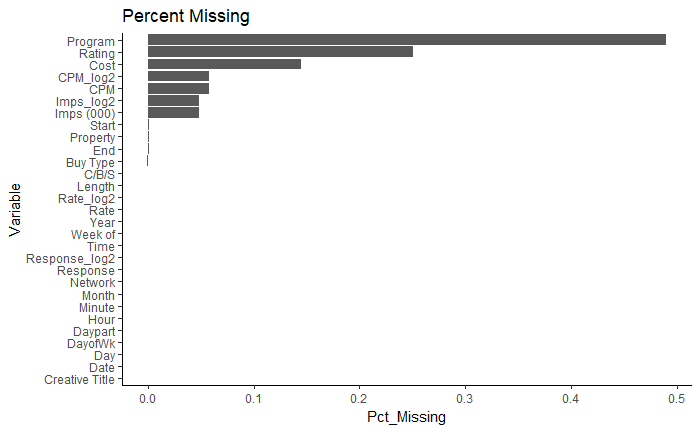

```r
# calculate percentage missing by variable
missing <- df %>%
  summarise_all(funs(sum(is.na(.)/n()))) %>%
  gather(key="Variable", value="Pct_Missing")
# create bar chart of percent missing
missing %>% ggplot(aes(x=reorder(Variable,Pct_Missing),y=Pct_Missing))+
  ggtitle("Percent Missing")+
  geom_bar(stat="identity")+
  xlab("Variable")+
  coord_flip()+
  theme_classic()
```

```r
# program and property look useful but will require some cleaning
df <- df %>%
  mutate_at(vars(Program, Property), str_to_lower) %>%
  mutate_at(vars(Program, Property), function(x) str_replace_all(string = x, pattern = "\\*|\\(|\\)", replacement = "")) %>%
  mutate_at(vars(Program, Property), str_trim)
df %>%
  group_by(Program, Property) %>%
  count() %>%
  arrange(desc(n))
```

| Program | Property | n |
| --- | --- | --- |
| NA | daytime | 6544 |
| NA | prime | 4431 |
| NA | fringe | 2894 |
| NA | weekend | 2426 |
| NA | day | 2261 |
| NA | late night | 1526 |
| NA | early fringe | 1157 |
| daytime ros m-f 6a-3p | daytime ros m-f 6a-3p | 1129 |
| bravo daytime-d m-f 8 am-3 pm | bravo daytime | 1080 |
| NA | daytime ros | 1076 |

[output cut: 990 more lines]

```r
# just keep non-zero for Response and Cost - model them later if necessary
tmp <- df %>% filter(CPM == 0 | Response == 0)
df <- df %>% filter(CPM > 0 & Response > 0)
# Select variables to keep in final dataset
df <- df %>%
  select(
    -Start, # Documentation says to ignore
    -End,  # Documentation says to ignore
    -`Week of`, # Redundant - same info as Date
    -`C/B/S`) # Too little variation
# Note the skewness in response
# df %$% boxplot(Response)
# Note the outlier in cost
# df %$% boxplot(CPM)
(outlier <- df %>% filter(CPM>100))
```

| Response | Date | Time | Network | Daypart | Rate | Imps (000) | CPM | Property | Buy Type | Length | Program | Creative Title | Year | Month | Day | DayofWk | Hour | Minute | Rating | Response_log2 | Cost | CPM_log2 | Rate_log2 | Imps_log2 |
| --- | --- | --- | --- | --- | --- | --- | --- | --- | --- | --- | --- | --- | --- | --- | --- | --- | --- | --- | --- | --- | --- | --- | --- | --- |
| 109 | 2016-08-06 | 1899-12-31 13:48:00 | Discovery | Weekend | 3680 | 230 | 306.67 | weekend | PE | 30 | NA | Walk-In Closet :30 | 2016 | Aug | 6 | Saturday | 13 | 48 | Very Good | 6.781360 | High | 8.26524 | 11.84588 | 7.851749 |
| 67 | 2016-08-07 | 1899-12-31 14:46:00 | Discovery | Weekend | 3680 | 230 | 306.67 | weekend | PE | 30 | NA | Bathroom :30 | 2016 | Aug | 7 | Sunday | 14 | 46 | Very Good | 6.087463 | High | 8.26524 | 11.84588 | 7.851749 |

```r
df <- df %>% filter(CPM<=100)
```

# Visualize

> Plot variables for exploratory data analysis
- Note the **skewnewss** in *Response*

| Variable | Description |
| --- | --- |
| **Response** | The number of website visits attributed to the airing the commercial |
| **Rate** | The amount of money paid for the commercial to air |
| **Imps (000)** | The number of individuals estimated to have watched the commercial |
| **CPM** | Rate divided by impressions = CPM (cost per thousand views) |

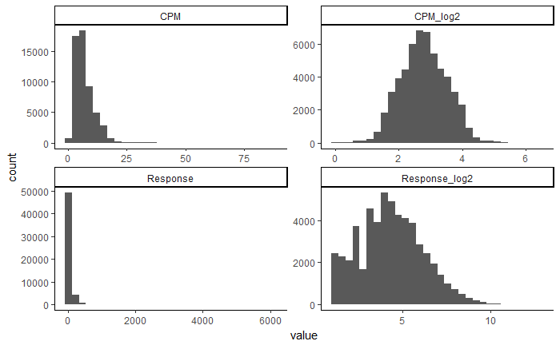

```r
df %>%
  select(Response, Response_log2, CPM, CPM_log2) %>%
  gather() %>%
  ggplot(aes(value)) +
  facet_wrap(~ key, scales = "free") +
  geom_histogram() + theme_classic()
```

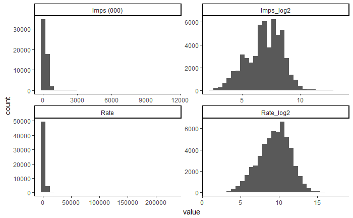

```r
# Impressions and Rate
df %>%
  select(Rate, Rate_log2, `Imps (000)`, Imps_log2) %>%
  gather() %>%
  ggplot(aes(value)) +
  facet_wrap(~ key, scales = "free") +
  geom_histogram() +
  # geom_density(fill = "gray", alpha = .5) +
  theme_classic()
```

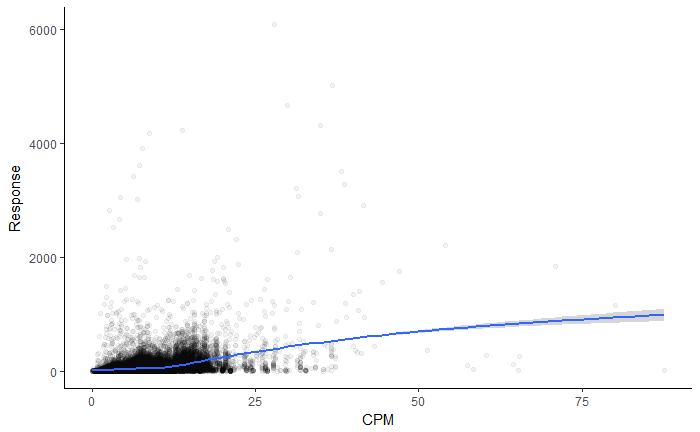

```r
# Response and Cost
df %>% select(Response, CPM) %>% ggplot(aes(CPM, Response)) + geom_point(alpha = .05, position = "jitter") + geom_smooth() + theme_classic()
```

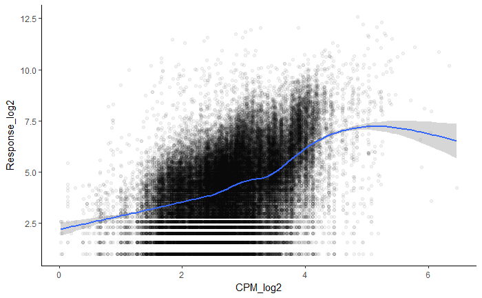

```r
df %>% select(Response_log2, CPM_log2) %>% ggplot(aes(CPM_log2, Response_log2)) + geom_point(position = "jitter", alpha = .05) + geom_smooth() + theme_classic()
```

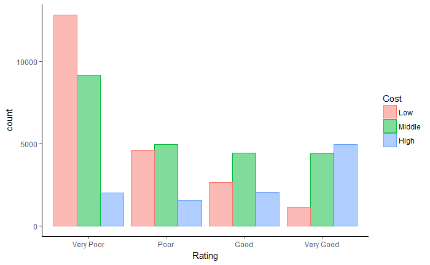

```r
df %>% select(Rating, Cost) %>% ggplot() + geom_bar(aes(Rating, fill = Cost, col = Cost), alpha = .5, position = "dodge") + theme_classic()
```

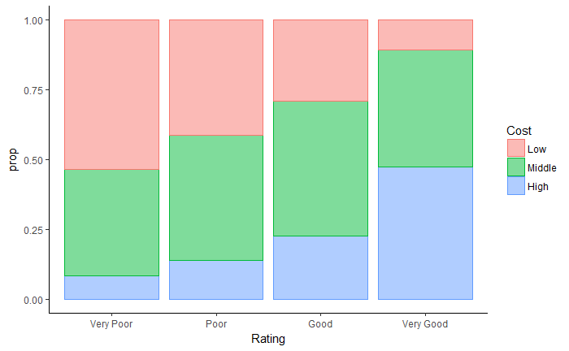

```r
df %>% select(Rating, Cost) %>% ggplot() + geom_bar(aes(Rating, fill = Cost, col = Cost), alpha = .5, position = "fill") + theme_classic() + ylab("prop")
```

| Variable | Description |
| --- | --- |
| **Date** | Date the commercial actually aired |
| **Time** | Time the commercial actually aired |
| **Daypart** | Defines the part of the day and week in which the commercial ran across all networks and media types |
| **Week of** | Starting Monday, the week in which the commercial aired; *same info as Date* |

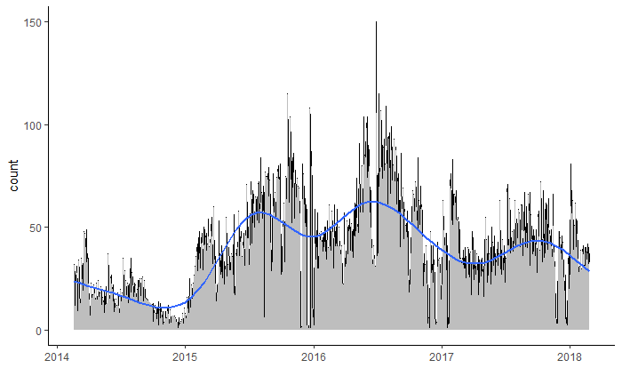

```r
# Date/Time 1
df %>%
  select(Date, Year) %>%
  group_by(Date, Year) %>%
  count() %>%
  # gather(key, value, -Year) %>%
  ggplot(aes(y = n, x = Date)) +
  # facet_grid(~Year, scales = "free") +
  xlab(label = "") +
  geom_line(col = "black") +
  geom_area(fill = "gray") +
  geom_smooth(aes(x=Date, y=n), se = F) + theme_classic() + ylab("count")
```

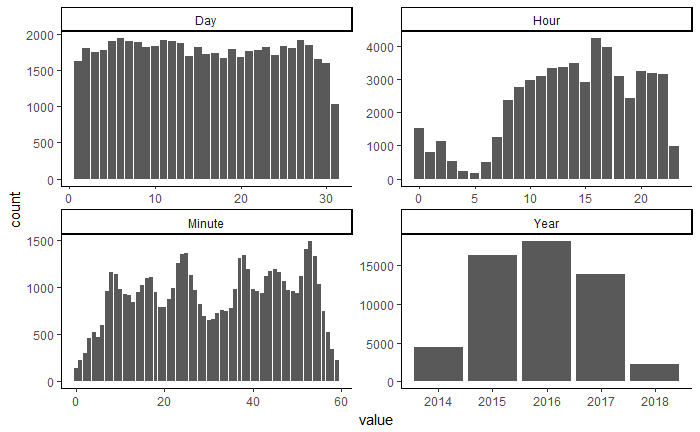

```r
# Date/Time 2
df %>%
  select(Year, Day, Hour, Minute) %>%
  gather() %>%
  ggplot(aes(value)) +
  facet_wrap(~key, scales = "free") +
  geom_bar() + theme_classic()
```

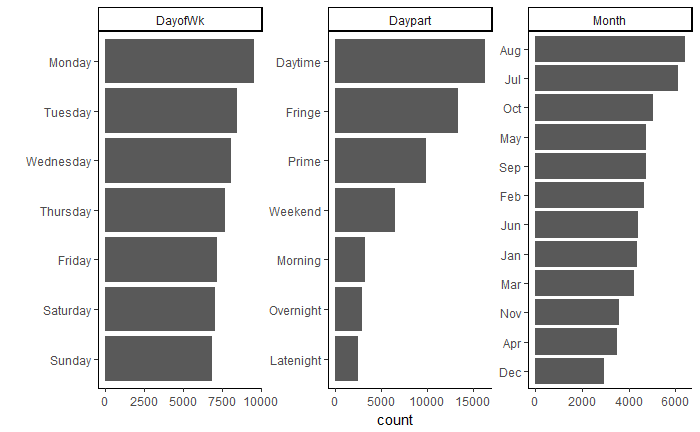

```r
# Date/Time 3
df %>%
  select(DayofWk, Daypart, Month) %>%
  select_if(is.character) %>%
  gather() %>%
  ggplot(aes(fct_rev(fct_infreq(value)))) +
  facet_wrap(~key, scales = "free") + xlab(label = "") +
  geom_bar() + coord_flip() + theme_classic()
```

| Variable | Description |
| --- | --- |
| **Length** | The length of the commercial which aired in seconds |
| **Buy Type** | Represents the different methods in which the property was purchased. |

```
attributes are not identical across measure variables;
they will be dropped
```

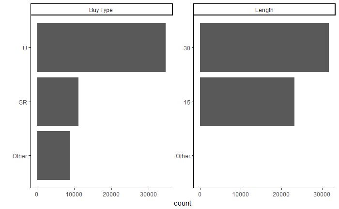

```r
# Bar charts 1
df %>%
  select(Length, `Buy Type`) %>%
  gather() %>%
  ggplot(aes(fct_relevel(fct_rev(fct_infreq(fct_lump(value, p = .1))), "Other"))) +
  facet_wrap(~key, scales = "free") + xlab(label = "") +
  geom_bar() + theme_classic() + coord_flip()
```

| Variable | Description |
| --- | --- |
| **Network** | Television channel in which the commercial was shown |

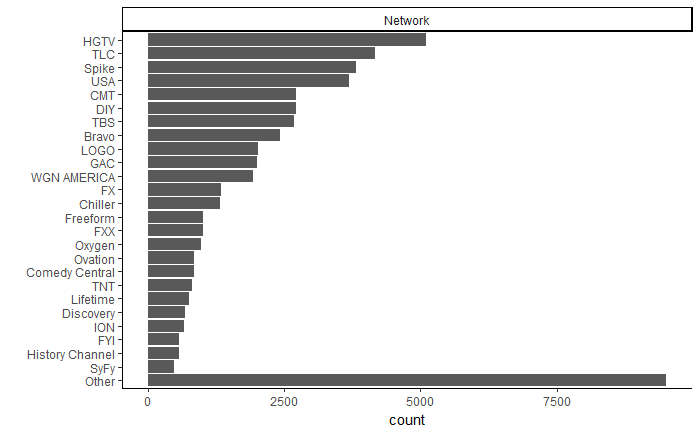

```r
# Bar charts 2
df %>%
  select(Network) %>%
  gather() %>%
  ggplot(aes(fct_relevel(fct_rev(fct_infreq(fct_lump(value, n = 25))), "Other"))) +
  facet_wrap(~key, scales = "free") + xlab(label = "") +
  geom_bar() + theme_classic() + coord_flip()
```

| Variable | Description |
| --- | --- |
| **Creative Title** | The name of the commercial that aired - some brands have different creatives on air at once. |

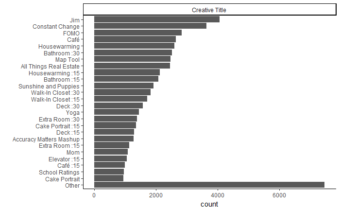

```r
# Bar charts 3
df %>%
  select(`Creative Title`) %>%
  gather() %>%
  ggplot(aes(fct_relevel(fct_rev(fct_infreq(fct_lump(value, n = 25))), "Other"))) +
  facet_wrap(~key, scales = "free") + xlab(label = "") +
  geom_bar() + theme_classic() + coord_flip()
```

| Variable | Description |
| --- | --- |
| **Program** | May resemble “Property” from above |

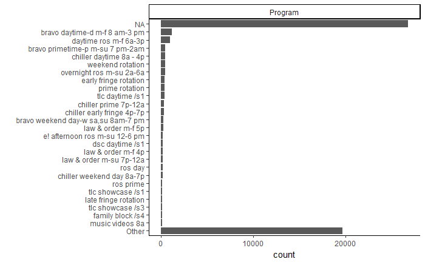

```r
# Bar charts 4
df %>%
  select(Program) %>%
  gather() %>%
  ggplot(aes(fct_relevel(fct_rev(fct_infreq(fct_lump(value, n = 25))), "Other"))) +
  facet_wrap(~key, scales = "free") + xlab(label = "") +
  geom_bar() + theme_classic() + coord_flip()
```

# Finalize

> Prepare the final dataset for modeling
- Drop columns tha are not relevant for modeling
- Examine pairwise correlations of continuous variables

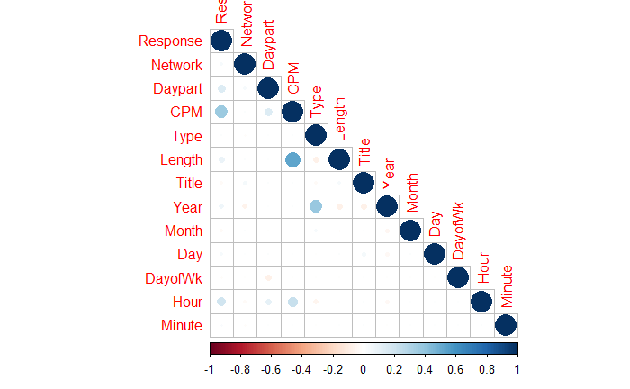

```r
dfnl <- df %>%
  select(
    -Date,
    -Time,
    -Program,
    -Property,
    -Rate,
    -Rate_log2,
    -`Imps (000)`,
    -Imps_log2) %>%
  rename(
    Type = `Buy Type`,
    Title = `Creative Title`) %>%
  mutate(
    Network = fct_lump(Network, p = .01),
    Daypart = fct_lump(Daypart, p = .01),
    Title = fct_lump(Title, p = .01),
    Year = as.factor(Year),
    DayofWk = as.factor(DayofWk),
    Month = as.factor(Month),
    Day = as.factor(Day),
    Hour = as.factor(Hour),
    Minute = as.factor(Minute))
cor <- dfnl %>%
  mutate_if(is.factor, as.numeric) %>%
  select(-c(Rating, Cost, Response_log2, CPM_log2)) %>%
  cor(use = "na.or.complete") %>%
  round(2)
# plot correlations
corrplot(cor, type = "lower") # order = "hclust", col = c("black", "white"), bg = "lightblue")
```

```r
# Export the final data as CSV
write_csv(dfnl, "final_data.csv", na = "")
```

# Model

> Run different types of models predicting response, assess validity and fit

```r
# start h2o
h2o.init(max_mem_size = "8192M")
```

[output not shown]

```r
h2o.no_progress()
# load data
dfh2o <- h2o.importFile("final_data.csv")
# partition
parts <- h2o.splitFrame(dfh2o,ratios = c(.7,.2))
train <- parts[[1]]
valid <- parts[[2]]
test  <- parts[[3]]
# Set predictor and response variables
myY <- "Response_log2"
myX <- c("Network","Daypart","Type","Length","Title","Year","Month","Day","DayofWk","Hour","Minute","CPM_log2")
# write custom functions
plot_scoring <- function(model) {
  sh <- h2o.scoreHistory(object = model)
  par(mfrow=c(1,2))
  if(model@algorithm == "gbm" | model@algorithm == "drf"){
    min <- min(range(sh$training_rmse), range(sh$validation_rmse))
    max <- max(range(sh$training_rmse), range(sh$validation_rmse))
    plot(x = sh$number_of_trees, y = sh$validation_rmse, col = "orange", main = model@model_id, ylim = c(min,max))
    points(x = sh$number_of_trees, y = sh$training_rmse, col = "blue")
    min <- min(range(sh$training_auc), range(sh$validation_auc))
    max <- max(range(sh$training_auc), range(sh$validation_auc))
    plot(x = sh$number_of_trees, y = sh$validation_auc, col = "orange", main = model@model_id, ylim = c(min,max))
    points(x = sh$number_of_trees, y = sh$training_auc, col = "blue")
    return(data.frame(number_of_trees = sh$number_of_trees, validation_auc = sh$validation_auc, validation_rmse = sh$validation_rmse))
  }
  if(model@algorithm == "deeplearning"){
    plot(x = sh$epochs, y = sh$validation_rmse, col = "orange", main = model@model_id)
    plot(x = sh$epochs, y = sh$validation_auc, col = "orange", main = model@model_id)
  }
}
```

> Build GLM

```r
start    <- Sys.time()
data.glm <- h2o.glm(
  y = myY,
  x = myX,
  training_frame = train,
  validation_frame = valid,
  family = "gaussian",
  standardize=T,
  model_id = "glm_model",
  alpha = 0.5,
  lambda = 1e-05)
glm_time <- Sys.time() - start
print(paste("Took", round(glm_time, digits = 2), units(glm_time), "to build regression model."))
```

```
[1] "Took 1.67 secs to build regression model."
```

> Plot coefficients

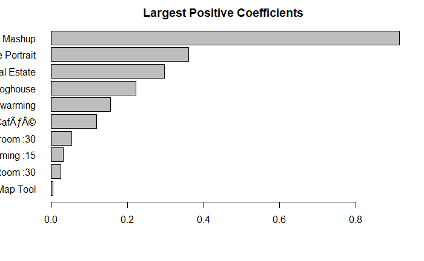

```r
top10pos <- data.glm@model$coefficients[-1][data.glm@model$coefficients[-1]>0][1:10]
top10neg <- data.glm@model$coefficients[-1][data.glm@model$coefficients[-1]<=0][1:10]
barplot(sort(top10pos), main = "Largest Positive Coefficients", horiz = T, las = 1)
```

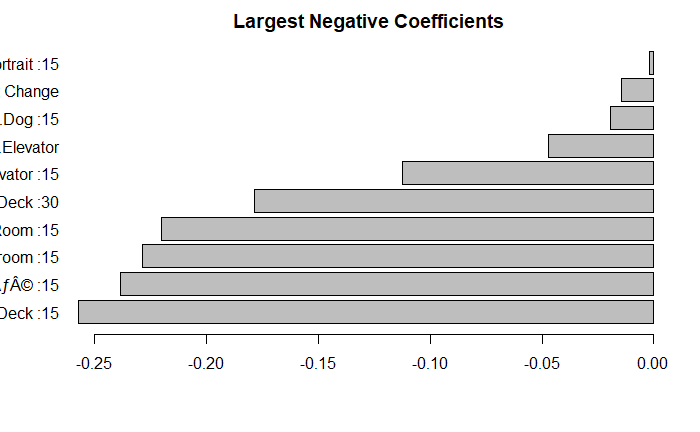

```r
barplot(sort(top10neg), main = "Largest Negative Coefficients", horiz = T, las = 1)
```

```r
summary(data.glm)
```

```
Model Details:
==============

H2ORegressionModel: glm
Model Key:  glm_model
GLM Model: summary
    family     link                              regularization number_of_predictors_total number_of_active_predictors
1 gaussian identity Elastic Net (alpha = 0.5, lambda = 1.0E-5 )                         97                          96
  number_of_iterations  training_frame
1                    1 RTMP_sid_903a_2

H2ORegressionMetrics: glm
** Reported on training data. **

MSE:  1.903425
RMSE:  1.379647
MAE:  1.084507
RMSLE:  0.3055846
Mean Residual Deviance :  1.903425
R^2 :  0.4251887
Null Deviance :126879.2
Null D.o.F. :38315
Residual Deviance :72931.62
Residual D.o.F. :38219
AIC :133594.4


H2ORegressionMetrics: glm
** Reported on validation data. **

MSE:  1.880316
RMSE:  1.371246
MAE:  1.074915
RMSLE:  0.3025576
Mean Residual Deviance :  1.880316
R^2 :  0.4255986
Null Deviance :36023.76
Null D.o.F. :11001
Residual Deviance :20687.24
Residual D.o.F. :10905
```

[output cut: 13 more lines]

```
            names coefficients sign
1        Type.PDR     2.565268  POS
2    Network.HGTV     1.741959  POS
3 Network.Ovation     1.288429  NEG
4    Network.LOGO     1.178355  NEG
5     Network.GAC     1.102923  NEG

---
                     names coefficients sign
92           Network.Other     0.006277  POS
93          Title.Map Tool     0.004038  POS
94               Month.Dec     0.003290  POS
95 Title.Cake Portrait :15     0.001943  NEG
96               Month.May     0.001418  NEG
97                  Type.D     0.000000  POS
```

> Build GBM Model

```r
start    <- Sys.time()
data.gbm <- h2o.gbm(
  y = myY,
  x = myX,
  training_frame = train,
  validation_frame = valid,
  ntrees = 100,
  max_depth = 5,
  model_id = "gbm_model",
  distribution = "gaussian",
  learn_rate = .1,
  min_rows = 2)
gbm_time <- Sys.time() - start
print(paste("Took", round(gbm_time, digits = 2), units(gbm_time), "to build a GBM model."))
```

```
[1] "Took 6.96 secs to build a GBM model."
```

> Build Random Forest Model

```r
start    <- Sys.time()
data.drf <- h2o.randomForest(
  y = myY,
  x = myX,
  training_frame = train,
  validation_frame = valid,
  ntrees = 150,
  max_depth = 5,
  model_id = "drf_model")
drf_time <- Sys.time() - start
print(paste("Took", round(drf_time, digits = 2), units(drf_time), "to build a Random Forest model."))
```

```
[1] "Took 6.09 secs to build a Random Forest model."
```

> Build Deep Learning Model

```r
start   <- Sys.time()
data.dl <- h2o.deeplearning(
  y = myY,
  x = myX,
  training_frame = train,
  validation_frame = valid,
  hidden=c(10, 10),
  epochs = 5,
  loss = "Automatic",
  variable_importances = T)
dl_time <- Sys.time() - start
print(paste("Took", round(dl_time, digits = 2), units(dl_time), "to build a Deep Learning model."))
```

```
[1] "Took 2.83 secs to build a Deep Learning model."
```

> Variable Importances

```r
# For feature selection and rerunning a model build
print("GLM: Sorted Standardized Coefficient Magnitudes To Find Nonzero Coefficients")
```

```
[1] "GLM: Sorted Standardized Coefficient Magnitudes To Find Nonzero Coefficients"
```

```r
data.glm@model$standardized_coefficient_magnitudes
```

```
Standardized Coefficient Magnitudes: standardized coefficient magnitudes
            names coefficients sign
1        Type.PDR     2.565268  POS
2    Network.HGTV     1.741959  POS
3 Network.Ovation     1.288429  NEG
4    Network.LOGO     1.178355  NEG
5     Network.GAC     1.102923  NEG

---
                     names coefficients sign
92           Network.Other     0.006277  POS
93          Title.Map Tool     0.004038  POS
94               Month.Dec     0.003290  POS
95 Title.Cake Portrait :15     0.001943  NEG
96               Month.May     0.001418  NEG
97                  Type.D     0.000000  POS
```

```r
print("GBM: Variable Importance")
```

```
[1] "GBM: Variable Importance"
```

```r
data.gbm@model$variable_importances
```

```
Variable Importances:
   variable relative_importance scaled_importance percentage
1   Network       116121.343750          1.000000   0.307847
2  CPM_log2       100701.507812          0.867209   0.266967
3   Daypart        53476.257812          0.460520   0.141770
4      Hour        37415.503906          0.322210   0.099191
5     Title        35245.175781          0.303520   0.093438
6     Month        11804.723633          0.101659   0.031295
7   DayofWk         6907.646484          0.059486   0.018313
8      Type         6245.169922          0.053781   0.016556
9    Minute         6109.967285          0.052617   0.016198
10     Year         1805.628662          0.015549   0.004787
11      Day         1372.408569          0.011819   0.003638
12   Length            0.000000          0.000000   0.000000
```

```r
print("Random Forest: Variable Importance")
```

```
[1] "Random Forest: Variable Importance"
```

```r
data.drf@model$variable_importances
```

```
Variable Importances:
   variable relative_importance scaled_importance percentage
1   Network      1789099.625000          1.000000   0.362305
2  CPM_log2      1418879.000000          0.793069   0.287333
3   Daypart       774332.125000          0.432805   0.156808
4      Hour       616835.000000          0.344774   0.124913
5     Title       187267.421875          0.104671   0.037923
6   DayofWk        38248.617188          0.021379   0.007746
7      Type        38075.632812          0.021282   0.007711
8    Length        28518.341797          0.015940   0.005775
9      Year        23896.376953          0.013357   0.004839
10    Month        18971.474609          0.010604   0.003842
11   Minute         3564.144531          0.001992   0.000722
12      Day          415.974884          0.000233   0.000084
```

```r
print("Deep Learning: Variable Importance")
```

```
[1] "Deep Learning: Variable Importance"
```

```r
data.dl@model$variable_importances
```

```
Variable Importances:
           variable relative_importance scaled_importance percentage
1 Daypart.Latenight            1.000000          1.000000   0.023225
2              Hour            0.935606          0.935606   0.021729
3      Network.HGTV            0.928218          0.928218   0.021557
4     Network.Other            0.895651          0.895651   0.020801
5       Network.USA            0.876588          0.876588   0.020358

---
               variable relative_importance scaled_importance percentage
98    Title.missing(NA)            0.000000          0.000000   0.000000
99  Network.missing(NA)            0.000000          0.000000   0.000000
100   Month.missing(NA)            0.000000          0.000000   0.000000
101    Type.missing(NA)            0.000000          0.000000   0.000000
102 Daypart.missing(NA)            0.000000          0.000000   0.000000
103 DayofWk.missing(NA)            0.000000          0.000000   0.000000
```

# Grid Search

> Build gbm models by running a grid over interaction depth

```r
grid_space1 <- list()
grid_space1$max_depth <- c(2,3,4,5,6)
grid_space1$ntrees <- c(500)
grid_space1$learn_rate <- c(0.01)
grid_space1$distribution <- c("gaussian")
my_gbm_grid <- h2o.grid(
  "gbm",
  x=myX,
  y=myY,
  training_frame=train,
  hyper_params=grid_space1)
print(my_gbm_grid)
```

```
H2O Grid Details
================

Grid ID: Grid_GBM_RTMP_sid_903a_2_model_R_1520538978734_2
Used hyper parameters:
  -  distribution
  -  learn_rate
  -  max_depth
  -  ntrees
Number of models: 5
Number of failed models: 0

Hyper-Parameter Search Summary: ordered by increasing residual_deviance
  distribution learn_rate max_depth ntrees                                                model_ids  residual_deviance
1     gaussian       0.01         6    500 Grid_GBM_RTMP_sid_903a_2_model_R_1520538978734_2_model_4 1.4660689199878507
2     gaussian       0.01         5    500 Grid_GBM_RTMP_sid_903a_2_model_R_1520538978734_2_model_3 1.5710809938530486
3     gaussian       0.01         4    500 Grid_GBM_RTMP_sid_903a_2_model_R_1520538978734_2_model_2 1.6682069233150478
4     gaussian       0.01         3    500 Grid_GBM_RTMP_sid_903a_2_model_R_1520538978734_2_model_1 1.7604611996635555
5     gaussian       0.01         2    500 Grid_GBM_RTMP_sid_903a_2_model_R_1520538978734_2_model_0 1.8825057737358792
```

> Build randomForest models by running a grid over ntrees

```r
grid_space2 <- list()
grid_space2$max_depth <- c(10)
grid_space2$ntrees <- c(50,100,200,300,400)
my_rf_grid <- h2o.grid(
  "randomForest",
  x=myX,
  y=myY,
  training_frame=train,
  validation_frame=valid,
  hyper_params=grid_space2)
print(my_rf_grid )
```

```
H2O Grid Details
================

Grid ID: Grid_DRF_RTMP_sid_903a_2_model_R_1520538978734_3
Used hyper parameters:
  -  max_depth
  -  ntrees
Number of models: 5
Number of failed models: 0

Hyper-Parameter Search Summary: ordered by increasing residual_deviance
  max_depth ntrees                                                model_ids  residual_deviance
1        10    400 Grid_DRF_RTMP_sid_903a_2_model_R_1520538978734_3_model_4 1.6595896044822702
2        10    300 Grid_DRF_RTMP_sid_903a_2_model_R_1520538978734_3_model_3  1.661515567321131
3        10    200 Grid_DRF_RTMP_sid_903a_2_model_R_1520538978734_3_model_2 1.6628160900386681
4        10    100 Grid_DRF_RTMP_sid_903a_2_model_R_1520538978734_3_model_1 1.6636699228355403
5        10     50 Grid_DRF_RTMP_sid_903a_2_model_R_1520538978734_3_model_0 1.6682902781180422
```

# Stop h2o

```r
h2o.shutdown(prompt = F)
```

```
[1] TRUE
```